# Simulation Results

### Simulation 6

- 6 covariates have an effect (+ or - or 0) that depends on a group
- 6 covariates have no effect

```
## [1] "AUC without covariates: 0.497"
```

```
## [1] "AUC with covariates: 0.744"
```

|  | GraphSVX | GRAD | GRADxInput | IG |
| --- | --- | --- | --- | --- |
| + | 0.50 | 0.79 | 0.55 | 0.65 |
| - | 0.51 | 0.79 | 0.51 | 0.34 |
| AUC | 0.46 | 0.43 | 0.70 | 0.75 |

- The black frames represent the estimated score for the additional variables $H$,
- The green frames represent the score for features where positive values are expected
- The red frames represent the score for features negative values are expected
- The blue frames are scores attributed to noise.

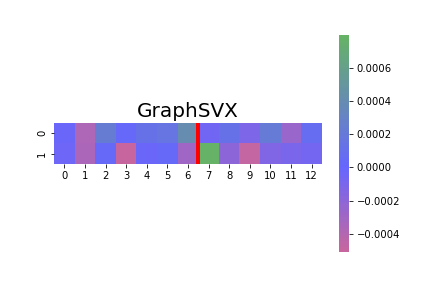

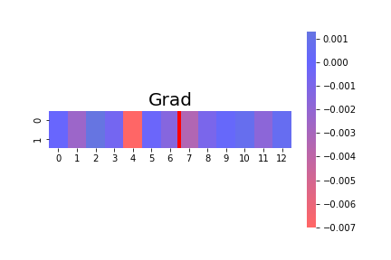

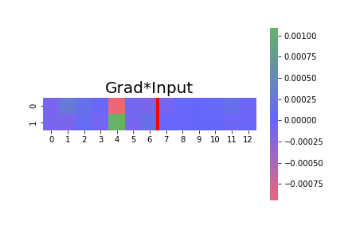

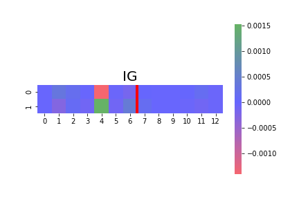

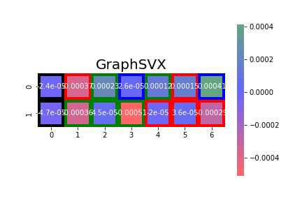

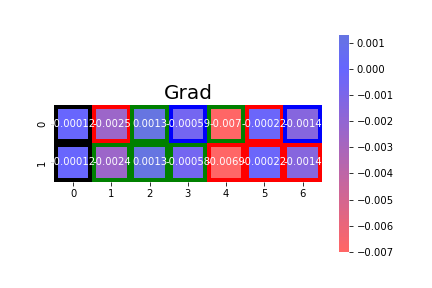

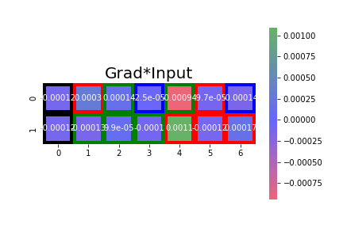

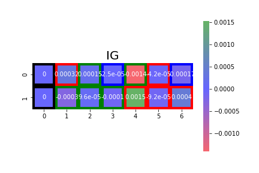

### Simulation 7

- 6 covariates have an effect (+ or -) that depends on a group
- 6 covariates have no effect
- the group is included as a covariate

```
## [1] "AUC without covariates: 0.497"
```

```
## [1] "AUC with covariates: 0.732"
```

|  | GraphSVX | GRAD | GRADxInput | IG |
| --- | --- | --- | --- | --- |
| + | 0.51 | 0.66 | 0.43 | 0.51 |
| - | 0.41 | 0.67 | 0.54 | 0.46 |
| AUC | 0.51 | 0.41 | 0.70 | 0.75 |

- The black frames represent the estimated score for the additional variables $H$,
- The green frames represent the score for features where positive values are expected
- The red frames represent the score for features negative values are expected
- The blue frames are scores attributed to noise.
- The sign “+” or “-” denotes the sign of the estimated score within each cell.

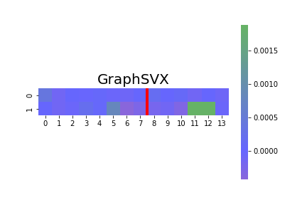

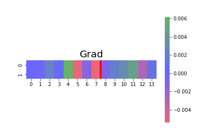

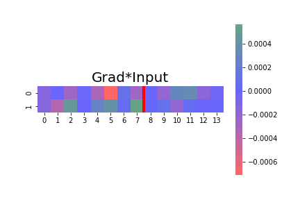

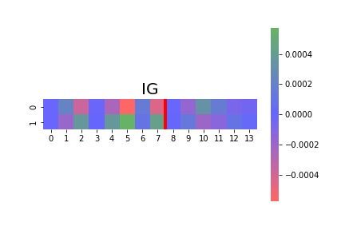

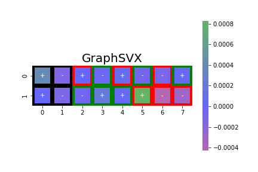

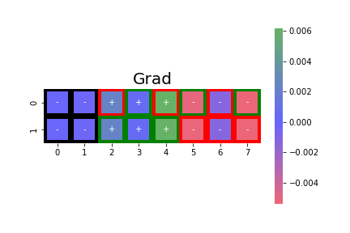

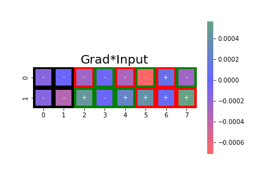

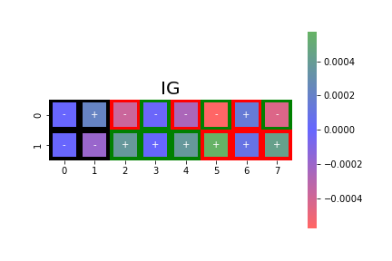

### Simulation 8

- 6 covariates have an effect (+ or - or 0) that depends on a group
- 6 covariates have no effect
- 4 groups with different effects

```
## [1] "AUC without covariates: 0.499"
```

```
## [1] "AUC with covariates: 0.74"
```

|  | GraphSVX | GRAD | GRADxInput | IG |
| --- | --- | --- | --- | --- |
| + | 0.53 | 0.79 | 0.53 | 0.60 |
| - | 0.46 | 0.79 | 0.52 | 0.40 |
| AUC | 0.51 | 0.37 | 0.57 | 0.59 |

- The black frames represent the estimated score for the additional variables $H$,
- The green frames represent the score for features where positive values are expected
- The red frames represent the score for features negative values are expected
- The blue frames are scores attributed to noise.
- The sign “+” or “-” denotes the sign of the estimated score within each cell.

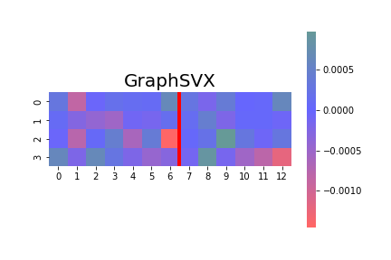

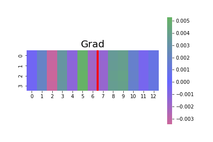

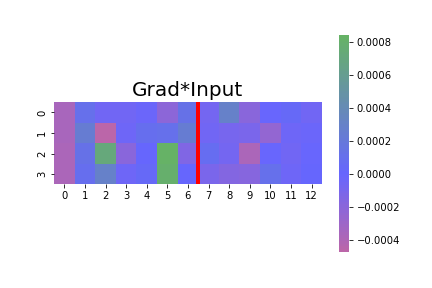

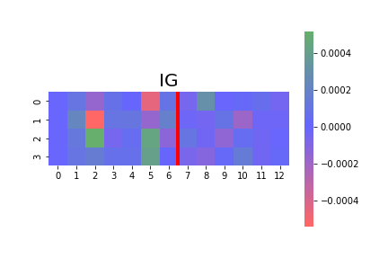

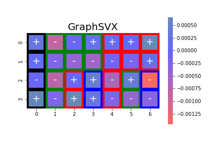

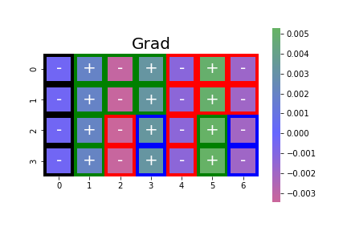

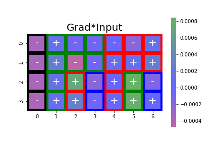

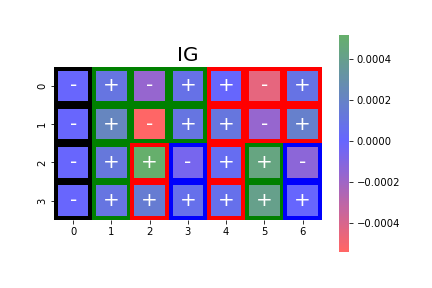

### Simulation 9

- 6 covariates have an effect (+ or - or 0) that depends on a group
- 6 covariates have no effect
- 4 groups with different effects
- the group is included as a covariate

```
## [1] "AUC without covariates: 0.497"
```

```
## [1] "AUC with covariates: 0.741"
```

|  | GraphSVX | GRAD | GRADxInput | IG |
| --- | --- | --- | --- | --- |
| + | 0.48 | 0.80 | 0.63 | 0.67 |
| - | 0.46 | 0.77 | 0.39 | 0.35 |
| AUC | 0.51 | 0.41 | 0.64 | 0.65 |

- The black frames represent the estimated score for the additional variables $H$,
- The green frames represent the score for features where positive values are expected
- The red frames represent the score for features negative values are expected
- The blue frames are scores attributed to noise.

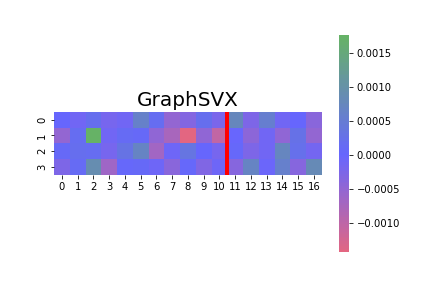

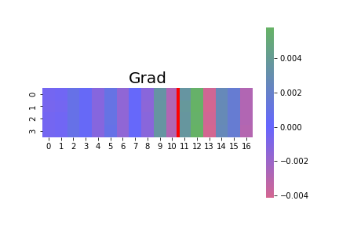

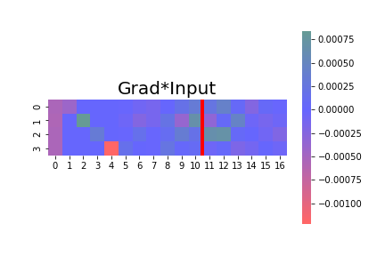

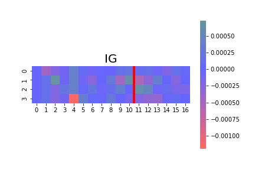

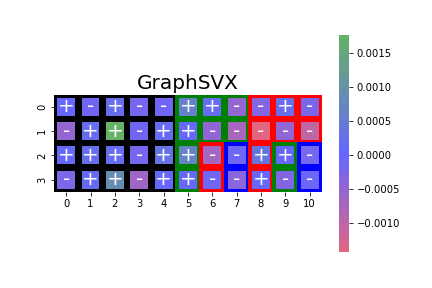

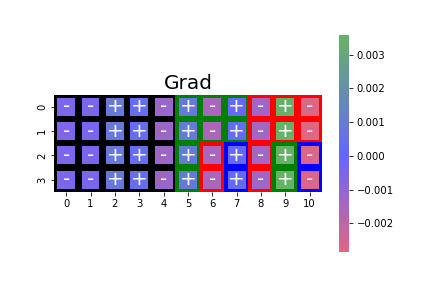

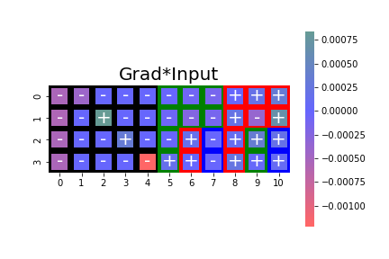

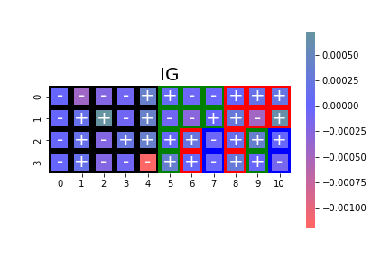

### Simulation 10

- 3 covariates have a positive effect
- 3 covariates have a negative effect
- 3 covariates have no effect
- The first covariate with a positive effect and the one with a negative effect are penalized with the HSIC

The goal is to see if the scores assigned to the variables penalized by the HSIC are smaller than the others.

```
## [1] "AUC without covariates: 0.501"
```

```
## [1] "AUC with covariates: 0.702"
```

|  | GraphSVX | GRAD | GRADxInput | IG |
| --- | --- | --- | --- | --- |
| + | 0.98 | 1.00 | 0.85 | 0.97 |
| - | 0.02 | 1.00 | 0.08 | 0.02 |
| AUC | 0.94 | 0.85 | 0.80 | 0.94 |

- The dashed line is positioned at zero.
- The black dot represents the estimated score for the additional variables $H$.
- The green dots represent the estimated score for features where positive values are expected.
- The red dots represent the estimated score for features where negative values are expected.
- The blue dots are scores attributed to noise.
- Variables penalized by the HSIC are represented with a cross.

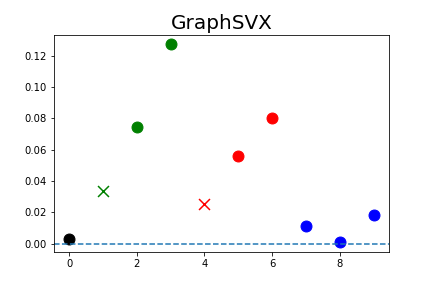

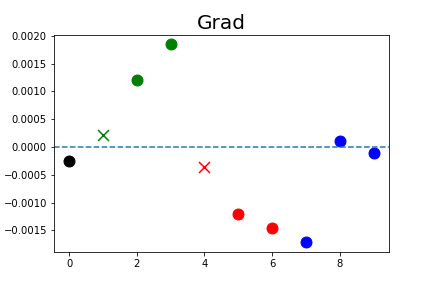

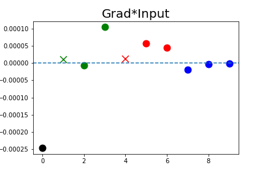

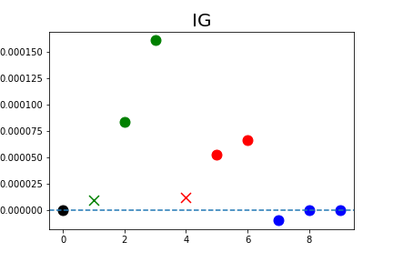

### Simulation 11

- 8 covariates have an effect (+ or -) that depends on a group
- 50 covariates have no effect
- The first covariate with a positive effect and the one with a negative effect are penalized with the HSIC

The goal is to see if the scores assigned to the variables penalized by the HSIC are smaller than the others.

```
## [1] "AUC without covariates: 0.502"
```

```
## [1] "AUC with covariates: 0.652"
```

|  | GraphSVX | GRAD | GRADxInput | IG |
| --- | --- | --- | --- | --- |
| + | 0.43 | 0.69 | 0.62 | 0.66 |
| - | 0.51 | 0.64 | 0.43 | 0.38 |
| AUC | 0.52 | 0.58 | 0.77 | 0.83 |

- The black frames represent the estimated score for the additional variables $H$,
- The green frames represent the score for features where positive values are expected
- The red frames represent the score for features negative values are expected
- The blue frames are scores attributed to noise or to variable penalized by the HSIC.

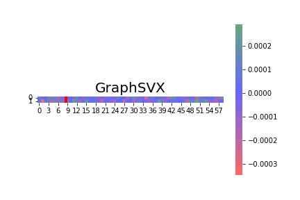

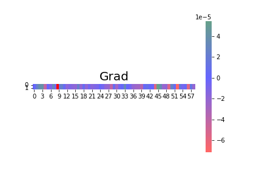

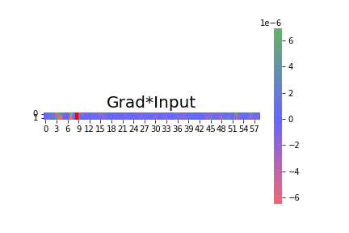

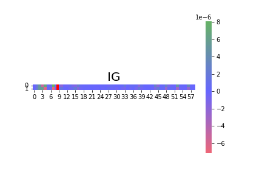

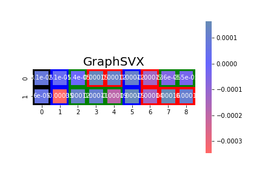

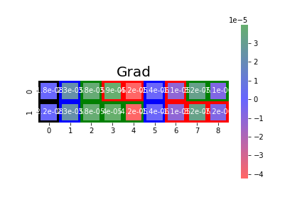

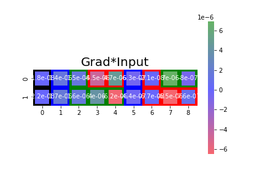

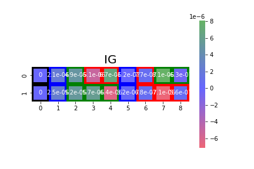

### Simulation 12

- 8 covariates have an effect (+ or - or 0) that depends on a group
- 8 covariates have no effect
- 4 groups with different effects
- 2 covariates are penalized with the HSIC

```
## [1] "AUC without covariates: 0.5"
```

```
## [1] "AUC with covariates: 0.67"
```

|  | GraphSVX | GRAD | GRADxInput | IG |
| --- | --- | --- | --- | --- |
| + | 0.47 | 0.66 | 0.39 | 0.47 |
| - | 0.48 | 0.67 | 0.57 | 0.45 |
| AUC | 0.51 | 0.44 | 0.62 | 0.65 |

- The black frames represent the estimated score for the additional variables $H$,
- The green frames represent the score for features where positive values are expected
- The red frames represent the score for features negative values are expected
- The blue frames are scores attributed to noise or to variable penalized by the HSIC.
- The sign “+” or “-” denotes the sign of the estimated score within each cell.

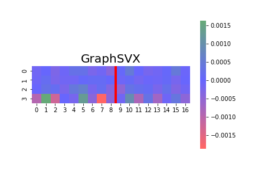

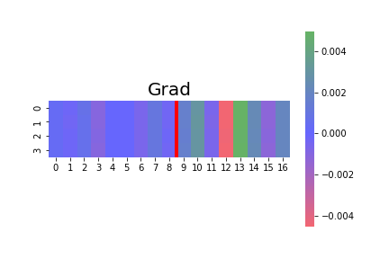

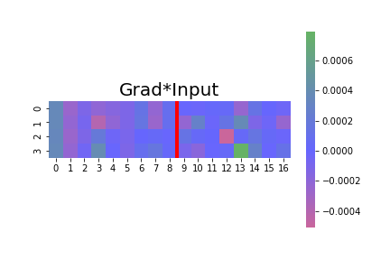

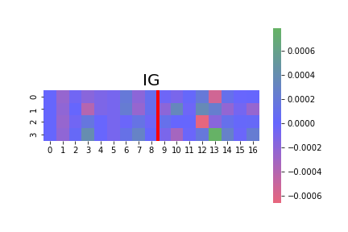

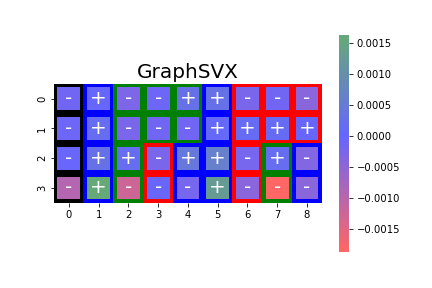

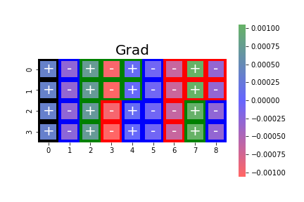

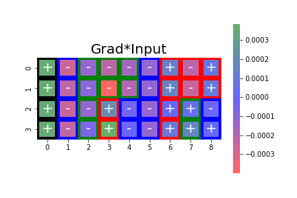

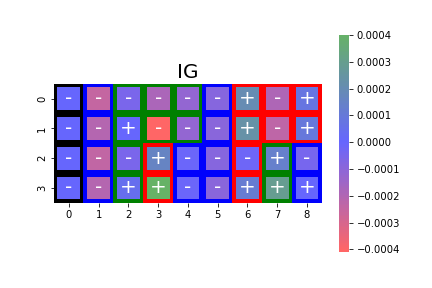

### Simulation 13

- 8 covariates have an effect (+ or - or 0) that depends on a group
- 8 covariates have no effect
- 4 groups with different effects
- 2 covariates are penalized with the HSIC
- the group is included as a covariate

```
## [1] "AUC without covariates: 0.499"
```

```
## [1] "AUC with covariates: 0.669"
```

|  | GraphSVX | GRAD | GRADxInput | IG |
| --- | --- | --- | --- | --- |
| + | 0.48 | 0.53 | 0.43 | 0.45 |
| - | 0.52 | 0.32 | 0.60 | 0.46 |
| AUC | 0.50 | 0.48 | 0.61 | 0.62 |

- The black frames represent the estimated score for the additional variables $H$,
- The green frames represent the score for features where positive values are expected
- The red frames represent the score for features negative values are expected
- The blue frames are scores attributed to noise or to variable penalized by the HSIC.
- The sign “+” or “-” denotes the sign of the estimated score within each cell.

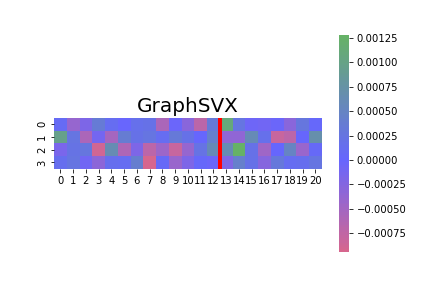

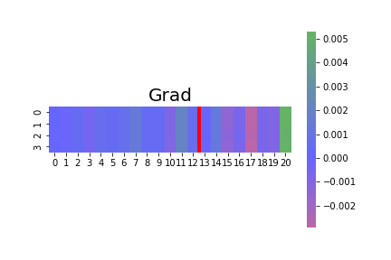

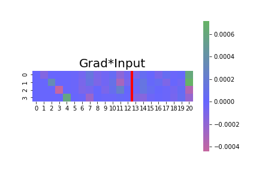

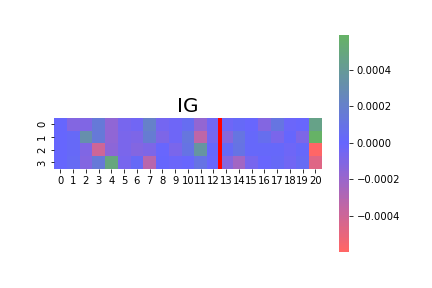

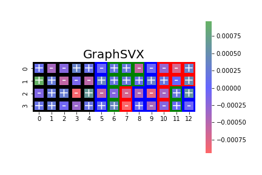

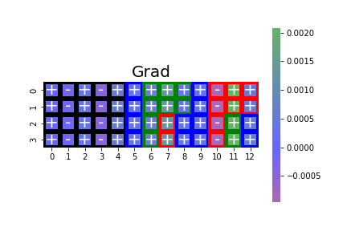

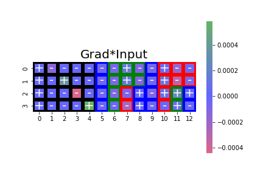

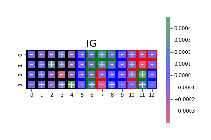